# PEC2 Software para el análisis de datos

Laura Sudupe

17/11/2020

Sección 1. Programación con R

EJERCICIO 1. Cuestiones de programación en R sobre el paquete de datos Airquality

```r
library(datasets)
data("airquality")
head(airquality)
```

```
##   Ozone Solar.R Wind Temp Month Day
## 1    41     190  7.4   67     5   1
## 2    36     118  8.0   72     5   2
## 3    12     149 12.6   74     5   3
## 4    18     313 11.5   62     5   4
## 5    NA      NA 14.3   56     5   5
## 6    28      NA 14.9   66     5   6
```

```r
df <- data.frame(airquality)
```

1. (0,6 puntos) La variable Wind representa la media de la velocidad del viento en unidades mph definida en diferentes momentos. Definid una función en R que devuelva la media de todos los valores registrados a la variable Wind y devuelva dicho valor.

```r
F_wind_mean <- function(x) {
  a <- mean(df$Wind, na.rm=FALSE)
  return(a)
  }

wind_mean <- F_wind_mean()
```

2. (0,6 puntos) La variable Temp representa la temperatura máxima en grados Farenheit en diferentes momentos. Definid una función en R que transforme los valores de la variable Temp de grado Farenheit a grados Celsius, teniendo en cuenta que: t (oC) = t (oF) -32/1,8.

```r
#definimos la funcion del cambio de temp
F_temp <- function(x){
  celcius <- (x - 32)/1.8
  return(celcius)
}

Temp_C <- sapply(df$Temp, F_temp)
```

3. (0,6 puntos) Definid una función que recorra todos los registros del dataframe airquality y asigne un valor 0 a todos las variables que tengan un valor NA.

```r
F_no_NA <- function(x){
  x[is.na(x)] <- 0
  return(x)
}

df_no_NA <- F_no_NA(df)
df_no_NA
```

```
##     Ozone Solar.R Wind Temp Month Day
## 1      41     190  7.4   67     5   1
## 2      36     118  8.0   72     5   2
## 3      12     149 12.6   74     5   3
## 4      18     313 11.5   62     5   4
## 5       0       0 14.3   56     5   5
## 6      28       0 14.9   66     5   6
## 7      23     299  8.6   65     5   7
## 8      19      99 13.8   59     5   8
## 9       8      19 20.1   61     5   9
## 10      0     194  8.6   69     5  10
## 11      7       0  6.9   74     5  11
## 12     16     256  9.7   69     5  12
## 13     11     290  9.2   66     5  13
## 14     14     274 10.9   68     5  14
```

[output cut: 139 more lines]

4. (0,6 puntos) Definid una función que, dado un valor numérico que corresponda a un mes determinado de la variable Month, muestre los valores de todas las temperaturas de la variable Temp que se han registrado ese mes.

```r
F_temp_in_month <- function(num){
  a <- subset(df$Temp, df$Month == num)
  return(a)
}
temp_month_five <- F_temp_in_month(5)
temp_month_five
```

```
##  [1] 67 72 74 62 56 66 65 59 61 69 74 69 66 68 58 64 66 57 68 62 59 73 61 61 57
## [26] 58 57 67 81 79 76
```

5. (0,6 puntos) Definid una función que muestre cuántas veces se han producido unos valores iguales o superiores a determinados de ozono y otro de radiación solar definidos por el usuario. Por ejemplo, ¿cuántas veces se ha producido un ozono mayor que 50 ppb, siendo una radiación igual o mayor a 200 lang?

```r
count <- 0
F_ozone_radiation <- function(x, y){
  a <- subset(df, df$Ozone == x | df$Solar.R == y)
  b <- length(a)
  return(b)
}
condition_1 <- F_ozone_radiation(50, 200)
condition_1
```

```
## [1] 6
```

EJERCICIO 2. Cuestiones de programación en R sobre secuencias de ADN aleatorias.

```r
#Vamos a crear una secuencia de ARN con las siguientes bases; A, G, U.

set.seed(9991)
base <- c("A", "G", "U")
longitud_seq <- 1000
n <- 1
secuencia <- replicate(n, paste0(sample(base,longitud_seq,replace = T),
                                 collapse = ""))
secuencia
```

```
## [1] "AAGUUUUAUAGUUAAGAGAGGUAGGUGUUAGGGGGUUUUUAUAGAGGGUAUUGUGGAGAA…"
```

```r
#Establecemos codones de stop y haremos un recuento de cuantas veces se repiten
codonesSTOP <- c("UAA", "UAG", "UGA")

library(stringr)
F_stop_codon <- function(secuence){
  count <- str_count(secuence, codonesSTOP)
  return(count)
}

stop_codons_secuence <- F_stop_codon(secuencia)
stop_codons_secuence
```

```
## [1] 37 34 46
```

```r
#obtenemos el numero de veces que aparece cada codon de parada
```

Sección 2. Distribuciones de probabilidad y simulación

EJERCICIO 3. Resolved los siguientes ejercicios utilizando Rstudio y Rcommander y comentar los resultados obtenidos.

1. La probabilidad de que, después de poner una determinada vacuna, una persona contraiga una determinada enfermedad contagiosa es del 4%.

• ¿Qué tipo de distribución representa este caso? Una distribución binomial. Tenemos dos resultados, que contraiga o no contraiga la enfermedad. En este caso, la probabilidad de que ocurra es constante y el resultado en cada prueba es independiente de los obtenidos anteriormente

• ¿Cuál es la probabilidad de que si se realiza la técnica 100 veces haya más de 5 casos en los que la vacuna no sea efectiva?

```r
prop_b <- 1 - pbinom(5,100,0.04, lower.tail = T)
prop_b
```

```
## [1] 0.2116251
```

• Representad en un diagrama de puntos la distribución que represente la probabilidad de que si se realiza la técnica a 80 casos, haya exactamente 4 contagios.

```r
par(mfrow=c(1,2))
prop_c <- dbinom(0:4,80,0.04)
prop_c
```

```
## [1] 0.03816793 0.12722644 0.20939352 0.22684298 0.18194698
```

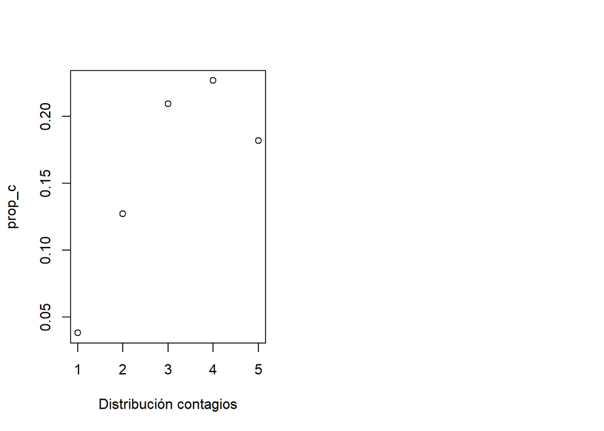

```r
plot(prop_c, xlab="Distribución contagios")
```

2. En general, la recuperación de una determinada intervención de varices es de aproximadamente 14 días de media, con una desviación estándar de 4 días. Si consideramos que estamos trabajando con una distribución normal, calcula la probabilidad de que dicha recuperación esté comprendida entre 12 y 16 días.

Calculamos la probabilidad como la resta entre la probabilidad de que dure 16 dias y la probabilidad de que dure 12 dias. Lo haremos con R-commander.

library(Rcmdr) Rcmdr> pnorm(c(16), mean=14, sd=4, lower.tail=TRUE) [1] 0.6914625 Rcmdr> pnorm(c(12), mean=14, sd=4, lower.tail=TRUE) [1] 0.3085375

```r
#Ahora realizamos la resta de ambos
prop_d <- (0.6914625-0.3085375)
prop_d
```

```
## [1] 0.382925
```

3. Los pacientes de una determinada ciudad tiene la posibilidad de realizar consultas a su médico de familia, a través de un portal web. Según los datos disponibles, mensualmente acceden una media de 1176 personas. Responde a las siguientes cuestiones:

• ¿Qué tipo de distribución representa este caso?

Una distribución de Poisson. Es una distribución de probabilidad discreta que expresa una frecuencia de ocurrencia media. Nos da la probabilidad de que ocurra un determinado número de eventos durante cierto periodo de tiempo.

• ¿Cuál es la probabilidad de qué, en un determinado mes, haya una media de 1200 accesos?

```r
prob_e <- dpois(c(0:1200),1176)
prob_e
```

[output not shown]

[output cut: 226 more lines]

• Representad en un diagrama de puntos el apartado anterior.

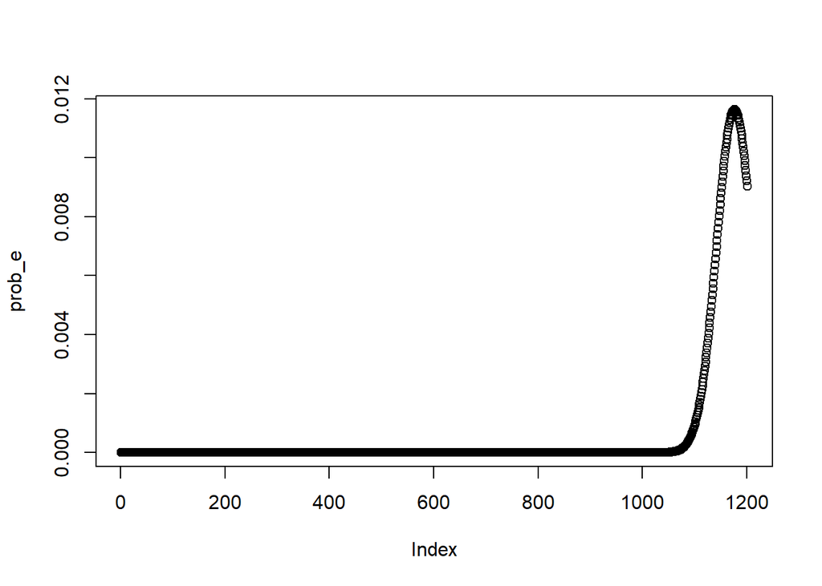

```r
plot(prob_e)
library(Rcmdr)
```

```r
library(Rcmdr)
```

EJERCICIO 4. Simulación en distribuciones de probabilidad

Según un estudio realizado, la probabilidad de que un portador de una determinada enfermedad altamente contagiosa la transmita a otras personas es de un 30%.

1. ¿De qué tipo de distribución se trata? Una distribución binomial
2. Utilizando Rstudio y/o Rcommander, generad 10000 valores aleatorios suponiendo que para cada 10 personas observadas, hay una probabilidad de 0.3 de que éstas sean contagiadas.

```r
muestra_b <- sample(c("contagiado","no-contagiado"),1000,rep=T,prob=c(0.3,0.7))
head(muestra_b)
```

```
## [1] "contagiado"    "no-contagiado" "no-contagiado" "no-contagiado"
## [5] "no-contagiado" "no-contagiado"
```

3. Representad en un histograma la anterior distribución.

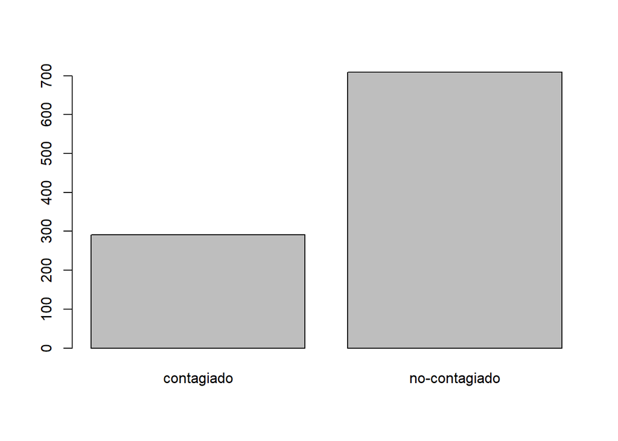

```r
plot(factor(muestra_b))
```

4. Repetid los apartados b) y c) para los casos correspondientes a 5, 100 y 1000 personas utilizando la funcion replicate(). ¿Qué podéis observar?

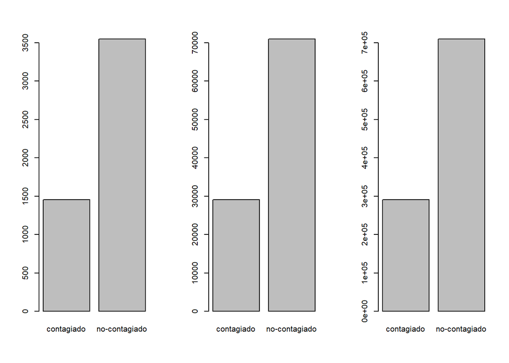

```r
par(mfrow=c(1,3))
numPer1 <- 5
repl1 <- replicate(numPer1, {
  muestra_b
})
plot(factor(repl1))

numPer2 <- 100
repl2 <- replicate(numPer2, {
  muestra_b
})
plot(factor(repl2))

numPer3 <- 1000
repl3 <- replicate(numPer3, {
  muestra_b
})
plot(factor(repl3))
```

Observamos que la distribución no cambia, pues no cambiamos la probabilidad, solo la muestra.

Sección 3. Machine learning con R

EJERCICIO 5.

A continuación se pide realizar un breve análisis de datos utilizando técnicas de machine learning.

Este estudio se realizará a partir del conjunto de datos epil del paquete MASS. Como orientación, recordad que tenéis que realizar; - un estudio de regresión lineal - regresión múltiple - test ANOVA - test clustering sobre dicho conjunto de datos. Las variables escogidas en cada uno de los casos posibles se dejan a elección del estudiante. Para desarrollar el ejercicio, podéis basaros en las pautas realizadas en el Caso práctico 1 del LAB5.

```r
#cargamos el paquete y el conjunto de datos
library(MASS)
data(epil)
head(epil)
```

```
##   y     trt base age V4 subject period      lbase       lage
## 1 5 placebo   11  31  0       1      1 -0.7563538 0.11420370
## 2 3 placebo   11  31  0       1      2 -0.7563538 0.11420370
## 3 3 placebo   11  31  0       1      3 -0.7563538 0.11420370
## 4 3 placebo   11  31  1       1      4 -0.7563538 0.11420370
## 5 3 placebo   11  30  0       2      1 -0.7563538 0.08141387
## 6 5 placebo   11  30  0       2      2 -0.7563538 0.08141387
```

```r
#eliminamos valores NA
data_epil <- na.omit(epil)
data_epil$trt <- factor(data_epil$trt, levels = c("placebo", "progabide"),
                        labels = c(0,1))
#convertimos todas las variable de int a num
data_epil$trt <- as.numeric(as.character(data_epil$trt))
```

Estudio de regresión lineal y multiple.

```r
#vamos a ver el tipo de variables
str(data_epil)
```

```
## 'data.frame':    236 obs. of  9 variables:
##  $ y      : int  5 3 3 3 3 5 3 3 2 4 ...
##  $ trt    : num  0 0 0 0 0 0 0 0 0 0 ...
##  $ base   : int  11 11 11 11 11 11 11 11 6 6 ...
##  $ age    : int  31 31 31 31 30 30 30 30 25 25 ...
##  $ V4     : int  0 0 0 1 0 0 0 1 0 0 ...
##  $ subject: int  1 1 1 1 2 2 2 2 3 3 ...
##  $ period : int  1 2 3 4 1 2 3 4 1 2 ...
##  $ lbase  : num  -0.756 -0.756 -0.756 -0.756 -0.756 ...
##  $ lage   : num  0.1142 0.1142 0.1142 0.1142 0.0814 ...
```

```r
#realizamos un breve estudio estadistico
summary(data_epil)
```

```
##        y                trt              base             age
##  Min.   :  0.000   Min.   :0.0000   Min.   :  6.00   Min.   :18.00
##  1st Qu.:  2.750   1st Qu.:0.0000   1st Qu.: 12.00   1st Qu.:23.00
##  Median :  4.000   Median :1.0000   Median : 22.00   Median :28.00
##  Mean   :  8.254   Mean   :0.5254   Mean   : 31.22   Mean   :28.34
##  3rd Qu.:  9.000   3rd Qu.:1.0000   3rd Qu.: 41.00   3rd Qu.:32.00
##  Max.   :102.000   Max.   :1.0000   Max.   :151.00   Max.   :42.00
##        V4          subject       period         lbase
##  Min.   :0.00   Min.   : 1   Min.   :1.00   Min.   :-1.36249
##  1st Qu.:0.00   1st Qu.:15   1st Qu.:1.75   1st Qu.:-0.66934
##  Median :0.00   Median :30   Median :2.50   Median :-0.06321
##  Mean   :0.25   Mean   :30   Mean   :2.50   Mean   : 0.00000
##  3rd Qu.:0.25   3rd Qu.:45   3rd Qu.:3.25   3rd Qu.: 0.55932
##  Max.   :1.00   Max.   :59   Max.   :4.00   Max.   : 1.86303
##       lage
##  Min.   :-0.42941
##  1st Qu.:-0.18429
##  Median : 0.01242
##  Mean   : 0.00000
##  3rd Qu.: 0.14595
##  Max.   : 0.41789
```

```r
#veamos cuales son las correlaciones entre variables
cor(x=data_epil, method = "pearson")
```

```
##                   y         trt        base         age          V4     subject
## y        1.00000000 -0.02515590  0.76201339 -0.05170506 -0.04447744  0.01631792
## trt     -0.02515590  1.00000000  0.01550034 -0.10054698  0.00000000  0.86502940
## base     0.76201339  0.01550034  1.00000000 -0.18897661  0.00000000  0.02491171
## age     -0.05170506 -0.10054698 -0.18897661  1.00000000  0.00000000 -0.04826695
## V4      -0.04447744  0.00000000  0.00000000  0.00000000  1.00000000  0.00000000
## subject  0.01631792  0.86502940  0.02491171 -0.04826695  0.00000000  1.00000000
## period  -0.04429553  0.00000000  0.00000000  0.00000000  0.77459667  0.00000000
## lbase    0.60391326  0.05232088  0.90377796 -0.16419488  0.00000000  0.06629633
## lage    -0.05172183 -0.11497942 -0.19843390  0.99368815  0.00000000 -0.06177138
##              period       lbase        lage
## y       -0.04429553  0.60391326 -0.05172183
## trt      0.00000000  0.05232088 -0.11497942
## base     0.00000000  0.90377796 -0.19843390
## age      0.00000000 -0.16419488  0.99368815
## V4       0.77459667  0.00000000  0.00000000
## subject  0.00000000  0.06629633 -0.06177138
## period   1.00000000  0.00000000  0.00000000
## lbase    0.00000000  1.00000000 -0.17689826
## lage     0.00000000 -0.17689826  1.00000000
```

Vemos una relación entre las variables “y”, “base”

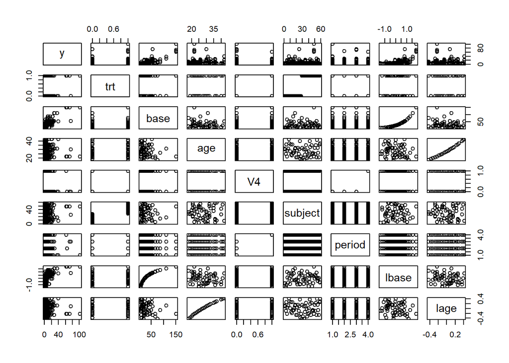

```r
#representamos la relación entre las variables
pairs(data_epil)
```

```r
#realizamos el modelo de regresión lineal
lineal_regre1 <- lm(formula=y~base,data=data_epil)
summary(lineal_regre1)
```

```
##
## Call:
## lm(formula = y ~ base, data = data_epil)
##
## Residuals:
##     Min      1Q  Median      3Q     Max
## -18.906  -3.581   0.085   2.222  59.368
##
## Coefficients:
##             Estimate Std. Error t value Pr(>|t|)
## (Intercept) -2.74505    0.80337  -3.417 0.000747 ***
## base         0.35231    0.01957  18.001  < 2e-16 ***
## ---
## Signif. codes:  0 '***' 0.001 '**' 0.01 '*' 0.05 '.' 0.1 ' ' 1
##
## Residual standard error: 8.012 on 234 degrees of freedom
## Multiple R-squared:  0.5807, Adjusted R-squared:  0.5789
## F-statistic:   324 on 1 and 234 DF,  p-value: < 2.2e-16
```

```r
#la formula
lm(formula = y ~ base, data = data_epil)
```

```
##
## Call:
## lm(formula = y ~ base, data = data_epil)
##
## Coefficients:
## (Intercept)         base
##     -2.7450       0.3523
```

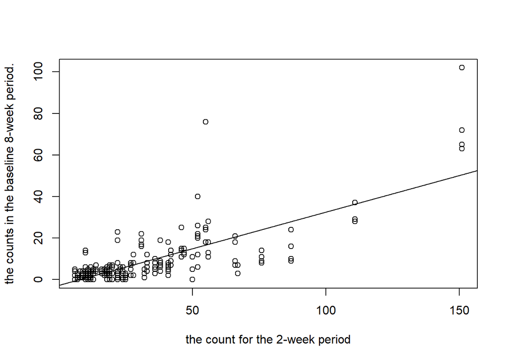

```r
#representamos el diagrama
plot(data_epil$base, data_epil$y,xlab = "the count for the 2-week period", ylab = "the counts in the baseline 8-week period.")
abline(lineal_regre1)
```

El modelo de regrasión lineal muestra “Multiple R-squared: 0.5807”, un ajuste decente.

Ahora realizaremos el modelo de regresión múltiple. Evaluaremos cuales son los posiblres predictores para la variable “y” .

```r
#Modelo de regresión múltiple
rmr_epil <- lm(data_epil$y~
                 data_epil$trt+data_epil$base+data_epil$age+data_epil$V4+
                 data_epil$subject+data_epil$period+data_epil$lbase+
                 data_epil$lage)
summary(rmr_epil)
```

```
##
## Call:
## lm(formula = data_epil$y ~ data_epil$trt + data_epil$base + data_epil$age +
##     data_epil$V4 + data_epil$subject + data_epil$period + data_epil$lbase +
##     data_epil$lage)
##
## Residuals:
##     Min      1Q  Median      3Q     Max
## -19.468  -3.147  -0.402   1.721  59.124
##
## Coefficients:
##                   Estimate Std. Error t value Pr(>|t|)
## (Intercept)       12.42481   20.26402   0.613    0.540
## data_epil$trt     -2.67071    1.98174  -1.348    0.179
## data_epil$base     0.55528    0.04351  12.763  < 2e-16 ***
## data_epil$age     -0.77249    0.71137  -1.086    0.279
## data_epil$V4      -0.72316    1.79602  -0.403    0.688
## data_epil$subject  0.08824    0.05785   1.525    0.129
## data_epil$period  -0.27119    0.69560  -0.390    0.697
## data_epil$lbase   -7.64052    1.55625  -4.910 1.74e-06 ***
## data_epil$lage    27.15598   20.08698   1.352    0.178
## ---
## Signif. codes:  0 '***' 0.001 '**' 0.01 '*' 0.05 '.' 0.1 ' ' 1
##
## Residual standard error: 7.556 on 227 degrees of freedom
## Multiple R-squared:  0.6382, Adjusted R-squared:  0.6255
## F-statistic: 50.06 on 8 and 227 DF,  p-value: < 2.2e-16
```

Ahora evaluamos cuáles son los mejores predictores

```r
step(object = rmr_epil, direction = "both", trace = 1)
```

```
## Start:  AIC=963.38
## data_epil$y ~ data_epil$trt + data_epil$base + data_epil$age +
##     data_epil$V4 + data_epil$subject + data_epil$period + data_epil$lbase +
##     data_epil$lage
##
##                     Df Sum of Sq   RSS     AIC
## - data_epil$period   1       8.7 12969  961.53
## - data_epil$V4       1       9.3 12970  961.54
## - data_epil$age      1      67.3 13028  962.60
## - data_epil$trt      1     103.7 13064  963.26
## - data_epil$lage     1     104.4 13065  963.27
## <none>                           12960  963.38
## - data_epil$subject  1     132.8 13093  963.78
## - data_epil$lbase    1    1376.2 14337  985.19
## - data_epil$base     1    9300.0 22261 1089.03
##
## Step:  AIC=961.53
## data_epil$y ~ data_epil$trt + data_epil$base + data_epil$age +
##     data_epil$V4 + data_epil$subject + data_epil$lbase + data_epil$lage
##
##                     Df Sum of Sq   RSS     AIC
## - data_epil$age      1      67.3 13036  960.76
## - data_epil$V4       1      70.9 13040  960.82
## - data_epil$trt      1     103.7 13073  961.41
## - data_epil$lage     1     104.4 13074  961.43
## <none>                           12969  961.53
## - data_epil$subject  1     132.8 13102  961.94
## + data_epil$period   1       8.7 12960  963.38
## - data_epil$lbase    1    1376.2 14345  983.34
## - data_epil$base     1    9300.0 22269 1087.12
##
## Step:  AIC=960.76
## data_epil$y ~ data_epil$trt + data_epil$base + data_epil$V4 +
##     data_epil$subject + data_epil$lbase + data_epil$lage
##
##                     Df Sum of Sq   RSS     AIC
## - data_epil$V4       1      70.9 13107  960.04
## <none>                           13036  960.76
## - data_epil$trt      1     111.8 13148  960.77
## - data_epil$subject  1     130.0 13166  961.10
## + data_epil$age      1      67.3 12969  961.53
## + data_epil$period   1       8.7 13028  962.60
## - data_epil$lage     1     329.4 13366  964.64
## - data_epil$lbase    1    1431.0 14468  983.34
## - data_epil$base     1    9368.6 22405 1086.56
##
## Step:  AIC=960.04
## data_epil$y ~ data_epil$trt + data_epil$base + data_epil$subject +
##     data_epil$lbase + data_epil$lage
##
##                     Df Sum of Sq   RSS     AIC
## <none>                           13107  960.04
## - data_epil$trt      1     111.8 13219  960.04
## - data_epil$subject  1     130.0 13237  960.37
## + data_epil$V4       1      70.9 13036  960.76
## + data_epil$period   1      70.3 13037  960.77
## + data_epil$age      1      67.3 13040  960.82
## - data_epil$lage     1     329.4 13437  963.89
## - data_epil$lbase    1    1431.0 14538  982.49
## - data_epil$base     1    9368.6 22476 1085.30
```

```
##
## Call:
## lm(formula = data_epil$y ~ data_epil$trt + data_epil$base + data_epil$subject +
##     data_epil$lbase + data_epil$lage)
##
## Coefficients:
##       (Intercept)      data_epil$trt     data_epil$base  data_epil$subject
##          -10.2977            -2.7702             0.5570             0.0873
##   data_epil$lbase     data_epil$lage
##           -7.7688             5.4846
```

En el resultado del “Call” se aprecian cuales seran los mejores predictores, calculamos de nuevo el modelo de regresión sobre estos

```r
#Modelo de regresión con los mejores predictores
rmr_epil_predictores <- lm(formula = data_epil$y ~ data_epil$trt +
                             data_epil$base + data_epil$subject +
                             data_epil$lbase + data_epil$lage)

summary(rmr_epil_predictores)
```

```
##
## Call:
## lm(formula = data_epil$y ~ data_epil$trt + data_epil$base + data_epil$subject +
##     data_epil$lbase + data_epil$lage)
##
## Residuals:
##     Min      1Q  Median      3Q     Max
## -19.939  -2.851  -0.330   1.965  59.663
##
## Coefficients:
##                    Estimate Std. Error t value Pr(>|t|)
## (Intercept)       -10.29767    1.79833  -5.726 3.19e-08 ***
## data_epil$trt      -2.77025    1.97778  -1.401    0.163
## data_epil$base      0.55696    0.04344  12.822  < 2e-16 ***
## data_epil$subject   0.08730    0.05779   1.511    0.132
## data_epil$lbase    -7.76879    1.55032  -5.011 1.08e-06 ***
## data_epil$lage      5.48461    2.28127   2.404    0.017 *
## ---
## Signif. codes:  0 '***' 0.001 '**' 0.01 '*' 0.05 '.' 0.1 ' ' 1
##
## Residual standard error: 7.549 on 230 degrees of freedom
## Multiple R-squared:  0.6341, Adjusted R-squared:  0.6262
## F-statistic: 79.73 on 5 and 230 DF,  p-value: < 2.2e-16
```

ANOVA

Ahora realizaremos el test ANOVA para las variables “trt” y “base”.

```r
#Definiremos los vectores de ambas variables
trt <- c(data_epil$trt)
base <- c(data_epil$base)

#Definimos un dataframe que guarde ambos vectores
df_anova <- data.frame(trt, base)
head(df_anova)
```

```
##   trt base
## 1   0   11
## 2   0   11
## 3   0   11
## 4   0   11
## 5   0   11
## 6   0   11
```

```r
#Mostramos el numero de observaciones por edad
table(df_anova$trt)
```

```
##
##   0   1
## 112 124
```

```r
#calculamos la media del recuento para ambos tratamientos)
aggregate(base~trt,data=df_anova,FUN=mean)
```

```
##   trt     base
## 1   0 30.78571
## 2   1 31.61290
```

Vemos que el número de observaciones no es constante, tenemos un modelo no-equilibrado. Hay que tenerlo en cuento al comprobar la normalidad y la homocedasticidad.

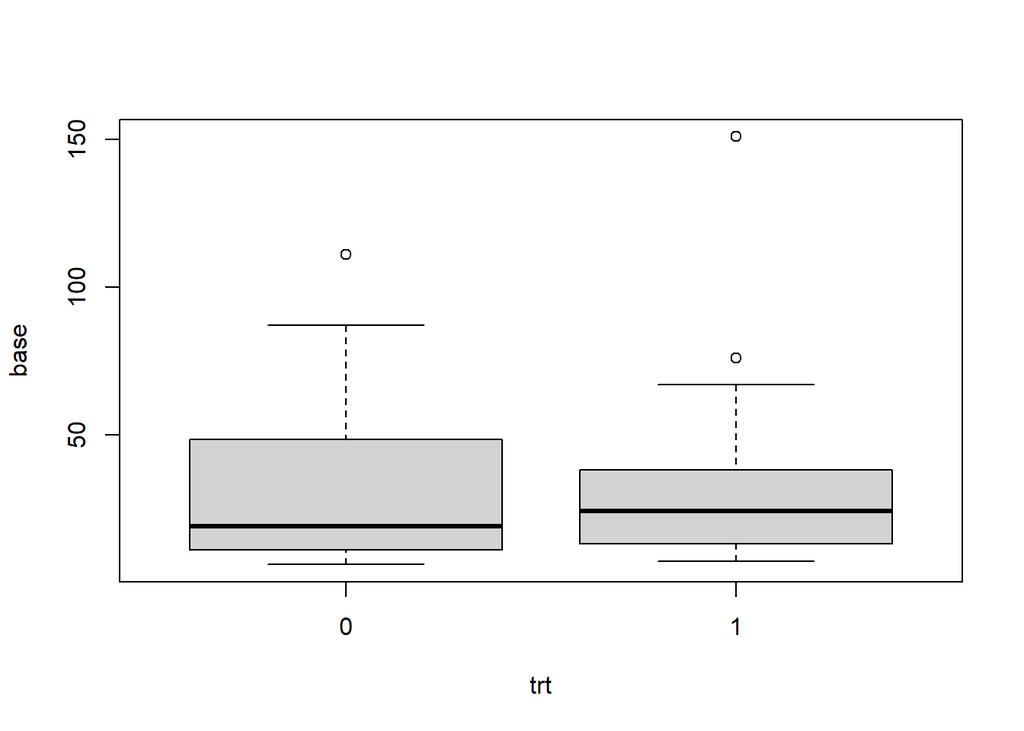

```r
#Calculamos el diagrama
boxplot(base~trt,data=df_anova,id.method="y")
```

Ahora verificaremos las condiciones para un ANOVA;

- Independencia: Disponemos de una muestra de estudio donde las observaciones de cada grupo son independientes.
- Normalidad: La variable cuantitativa debe de distribuirse de forma normal en cada uno de los grupos. El estudio de la normalidad puede hacerse de forma gráfica o con test de hipotesis.

```r
df_anova
```

```
##     trt base
## 1     0   11
## 2     0   11
## 3     0   11
## 4     0   11
## 5     0   11
## 6     0   11
## 7     0   11
## 8     0   11
## 9     0    6
## 10    0    6
## 11    0    6
## 12    0    6
## 13    0    8
## 14    0    8
```

[output cut: 222 more lines]

```r
#Estudio de la normalidad, Test Kolmogorov-Smirnov
require(nortest)
by(data=df_anova, INDICES =
     df_anova$trt, FUN = function(x){lillie.test(x$base)})
```

```
## df_anova$trt: 0
##
##  Lilliefors (Kolmogorov-Smirnov) normality test
##
## data:  x$base
## D = 0.19806, p-value = 1.088e-11
##
## ------------------------------------------------------------
## df_anova$trt: 1
##
##  Lilliefors (Kolmogorov-Smirnov) normality test
##
## data:  x$base
## D = 0.20577, p-value = 4.447e-14
```

Observamos que p_valor inferior a 0.05, por lo tanto, sabemos que no se cumplen las condiciones de normalidad. No teniendo sentido realizar el test de ANOVA.

CLUSTERING

A continuación realizaremos el test de Clustering.

Comenzamos con un agrupamiento jerárquico aglomerativo. Cada observación sera un clúster que se va a ir organizando hasta converger en una única rama central.

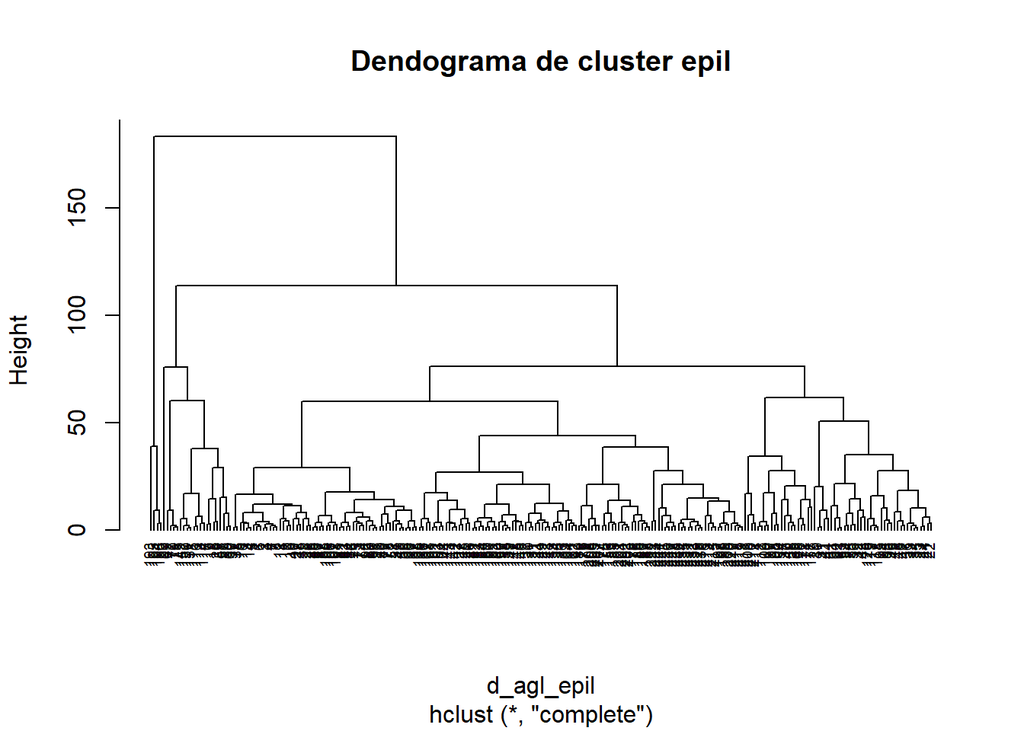

```r
library(cluster)
#especificamos los valores de distancia
d_agl_epil <- dist(data_epil, method = "euclidean")

#calculamos el cluster jerárquico
hc_agl_epil <- hclust(d_agl_epil, method = "complete")

#representamos el dendograma
plot(hc_agl_epil, cex=0.6, hang=-1, main = "Dendograma de cluster epil")
```

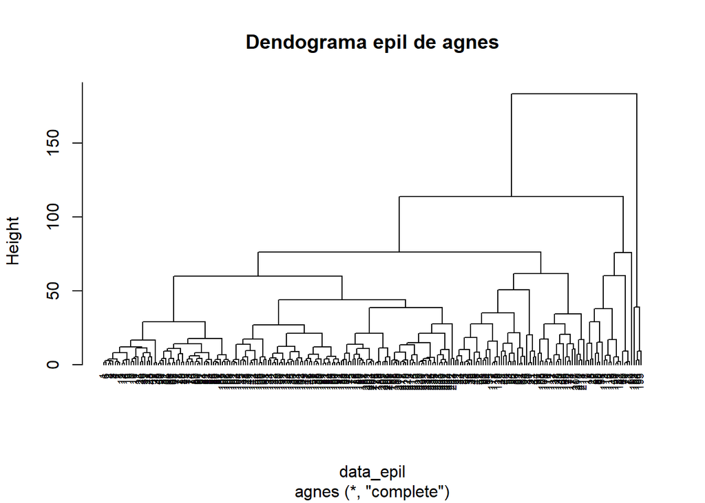

```r
#Calculamos los clusteres jerárquicos
hc_ag_epil <- agnes(data_epil, method = "complete")

#Representamos el dendograma
pltree(hc_ag_epil, cex=0.6, hang=-1, main="Dendograma epil de agnes")
```

```r
#Calculamos el coeficiente de aglomeración
hc_ag_epil$ac
```

```
## [1] 0.980928
```

Tenemos un coeficiente muy cercano a 1, indicandonos que la agrupación es fuerte.

Sección 4. Investigación de herramientas d R

EJERCICIO 6. Ampliación R Realizad un breve estudio a escoger entre los siguientes temas:

R representa información en mapas utilizando el paquete ggmap. Localizad una aplicación (https://www.rdocumentation.org/packages/ggmap/versions/2.6.2 ) que pueda tener un uso potencial en bioinformática/bioestadística.

Podria usarse ggmap para obtener mapas del genoma. Por ejemplo, en USCS se hacen mapas del genoma en dos dimensiones con las coordenadas de los genes.

ggmap tiene diversas funciones que se pueden dividir en 3 categorias; - Obtención de mapas de diversas fuentes. Para el proposito de la bioinformatica, estos mapas se podrian obtener de los “genome browser” de diversas paginas.

- Tiene funciones utilizan APIs de Google por ejemplo. En nuestro caso abria que modificarlo a buscadores que nos pudieran interesar. Consultar la información de distintos proveedores via API sobre las coordenadas de un cromosoma determinado.
- Funciones que pintan mapas y representan determinador elementos. En el caso de la bioinformatica podrian ser diferentes codones, islas GC o variedades de caracteristicas geneticas a tener en cuenta. Esta funcionalidad por ejemplo, si se esta llevando a cabo un determinado estudio, podria usarse geom_point() dentro de ggmap() para agregar marcadores en nucleotidos señalados.